# JaleshRFXGBoost

train test split

```python
xt, xtest, yt, ytest = train_test_split(df.ClenedText_W2Vtfdf, df.Score, test_size=0.2, shuffle=False)
xtr, xcv, ytr, ycv = train_test_split(xt, yt, test_size=0.2, shuffle=False)
```

tf-Idf featurizer

```python
%%time
from sklearn.feature_extraction.text import TfidfVectorizer

tfidf_object = TfidfVectorizer(ngram_range=(1,1))
xtr = tfidf_object.fit_transform(xtr)
xcv = tfidf_object.transform(xcv)
xtest = tfidf_object.transform(xtest)
```

```
CPU times: user 4.04 s, sys: 176 ms, total: 4.22 s
Wall time: 4.25 s
```

TFIDF instance creation

```python
import time
start = time.time()
Tfidf_instance = XGB(xtr, ytr, xcv, ycv)

dictionary_train, dictionary_cv = Tfidf_instance.classfier()
end = time.time()

print('time is(in seconds): ', end - start)
```

```
1 10
2 10
3 10
4 10
1 20
2 20
3 20
4 20
1 30
2 30
3 30
4 30
1 40
2 40
3 40
```

[output cut: 18 more lines]

Sorting the data based off AUC score

```python
train_list = [[np.round(x, 5), y] for x, y in dictionary_train.items()]
cv_list = [[np.round(x, 5), y] for x, y in dictionary_cv.items()]

print(train_list[0])

print()
print(cv_list[0])

tr_list = sorted(train_list, key=lambda x: x[0], reverse=True)
cv_list = sorted(cv_list, key=lambda x: x[0], reverse=True)
print('sorted train list score based off AUC score is:\n', tr_list[0:3])
print('****************************************')
print()
print('sorted CV list score based off AUC score is:\n', cv_list[0:3])
```

```
[0.69475, [10, 1]]

[0.70502, [10, 1]]
sorted train list score based off AUC score is:
 [[0.90007, [80, 4]], [0.89601, [80, 4]], [0.89338, [70, 4]]]

sorted CV list score based off AUC score is:
 [[0.88303, [80, 4]], [0.88201, [80, 4]], [0.87755, [70, 4]]]
```

AUC Curve on training and cv data based off depth

[figure not shown]

```python
plt.plot([x[0] for x in tr_list], [x[1][1] for x in tr_list], linestyle='-', color='m', marker='o',label='AUC on CV data')
plt.plot([x[0] for x in cv_list], [x[1][1] for x in cv_list], linestyle='-', color='g', marker='o', label='AUC on TR data')
#plt.plot([0, 1], [0, 1], linestyle='--')
plt.xlabel("no of base_classifiers")
plt.ylabel('AUC value')
plt.title('auc of Training and cross validation data points')
plt.legend()
```

OptimalTFidf - XGBoost[depth = 4 and basemodels = 80]

```python
clfxgb = XGBClassifier(booster='gbtree',silent=0,max_depth=4, n_estimators=80, learning_rate=0.1, class_weight='balanced')
clfxgb.fit(xtr, ytr)

#prediction on training data:
y_pred_tr = clfxgb.predict_proba(xtr)
fpr_tr, tpr_tr, thresholds_tr= roc_curve(ytr, y_pred_tr[:,1])
auc_tr = auc(fpr_tr, tpr_tr)

#prediction on test data:
ypred = clfxgb.predict_proba(xtest)
fpr_test, tpr_test, thresholds_test= roc_curve(ytest, ypred[:,1])
auc_test = auc(fpr_test, tpr_test)

print(auc_test)
```

```
0.8832488039437586
```

Confusion matrix on test data

```
CPU times: user 0 ns, sys: 0 ns, total: 0 ns
Wall time: 7.39 µs
```

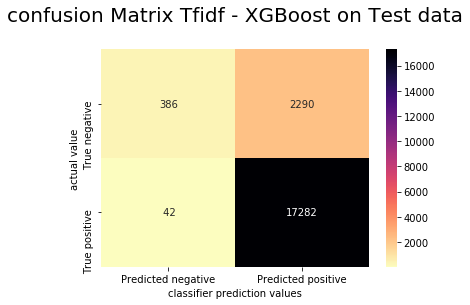

```python
%time
ypred = np.where(ypred[:,1] < 0.5, 0, 1)
#creating confusion matrix:

cf = confusion_matrix(ytest, ypred)
labels = ['True negative', 'True positive']

df_cf = pd.DataFrame(cf, index=labels, columns=['Predicted negative', 'Predicted positive'])
sns.heatmap(df_cf, annot=True,fmt='3d', cmap='magma_r')

plt.title("confusion Matrix Tfidf - XGBoost on Test data\n", size=20)
plt.xlabel("classifier prediction values")
plt.ylabel("actual value")
plt.show()
```

Confusion matrix on training data

```
CPU times: user 0 ns, sys: 0 ns, total: 0 ns
Wall time: 7.39 µs
```

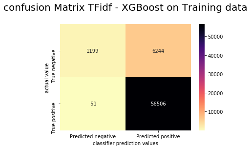

```python
%time
y_pred_tr = np.where(y_pred_tr[:,1] < 0.5, 0, 1)
#creating confusion matrix:

cf = confusion_matrix(ytr, y_pred_tr)
labels = ['True negative', 'True positive']

df_cf = pd.DataFrame(cf, index=labels, columns=['Predicted negative', 'Predicted positive'])
sns.heatmap(df_cf, annot=True,fmt='3d', cmap='magma_r')

plt.title("confusion Matrix TFidf - XGBoost on Training data\n", size=20)
plt.xlabel("classifier prediction values")
plt.ylabel("actual value")
plt.show()
```

ROC curve - training vs test data

[figure not shown]

```python
plt.plot(fpr_test, tpr_test, color='m', marker='o',label='ROC -testdata')
plt.plot([0, 1], [0, 1], linestyle='--')
plt.plot(fpr_tr, tpr_tr, linestyle='-', color='g', marker='o', label='ROC - training data')
plt.xlabel('False Positive Rate')
plt.ylabel('True Positive Rate')
plt.title('BoW ROC of Test vs Training Data\n', size=20)
plt.legend()
```

Feature Importance

```python
features = tfidf_object.get_feature_names()
featuresAndcoeff = sorted(zip(clfxgb.feature_importances_, features))
top_features = zip(featuresAndcoeff[:25],featuresAndcoeff[:-(25+1): -1] )
print('\t\t\t\tNegative\t\t\t\t\t\t\tPositive')
print('-' * 120)

for (wn1, fn1), (wp1, fp1) in top_features:
    print('{:>20} {:>20}                                {:>20} {:>20}'.format(wn1, fn1, wp1, fp1))
```

```
				Negative							Positive
------------------------------------------------------------------------------------------------------------------------
                 0.0                  aaa                                 0.01900656148791313                 best
                 0.0        aaaaaaaaagghh                                 0.01840704120695591             horrible
                 0.0               aaaaah                                0.017405742779374123                  not
                 0.0 aaaaahhhhhhhhhhhhhhhh                                 0.01619257591664791                money
                 0.0                aaaah                                0.016128158196806908                great
                 0.0                 aaah                                0.015471220016479492             received
                 0.0                aaahs                                0.015331736765801907         disappointed
                 0.0               aachen                                 0.01469665952026844                  bad
                 0.0                  aad                                 0.01462656632065773                threw
                 0.0                 aadp                                0.014441183768212795                gross
                 0.0                aafco                                0.014279133640229702            delicious
                 0.0                 aagh                                0.014184785075485706                 didn
                 0.0               aahhed                                0.014178333804011345           disgusting
                 0.0               aahing                                 0.01414472982287407            wonderful
                 0.0                 aand                                0.014046834781765938                sorry
                 0.0             aardvark                                0.013720561750233173               return
                 0.0                aback                                0.013659702613949776          description
                 0.0              abandon                                0.013600846752524376                worst
                 0.0            abandoned                                0.013287031091749668               highly
                 0.0           abandoning                                 0.01327624823898077            excellent
                 0.0           abaolutely                                0.013225429691374302               beware
                 0.0             abattoir                                0.013210281729698181               refund
                 0.0                 abba                                0.013103865087032318                worse
                 0.0                abbey                                0.013080248609185219             favorite
                 0.0          abbreviated                                 0.01298781018704176            tasteless
```

Since for negative class we are observing many features having feature importance values coming as 0,I m discarding all the features having 0 feature importance values and then printing the output of yop 25 features below:

```python
features = bow_object.get_feature_names()
featuresAndcoeff = sorted(zip(clfxgb.feature_importances_, features))
l = []
for a, b in featuresAndcoeff:
    if a == 0:
        continue
    else:
        l.append([a,b])

l = sorted(l, key=lambda x: x[0], reverse=True)
positive = l[:25]
negative = l[-(25 + 1): -1]
a = dict(top25_pos=positive,top25_neg=negative)
dataframe = pd.DataFrame(a)
dataframe
```

|  | top25_neg | top25_pos |
| --- | --- | --- |
| 0 | [0.0007298733, bartlet] | [0.019006561, bullet] |
| 1 | [0.0007202348, retest] | [0.018407041, osu] |
| 2 | [0.00068993523, vice] | [0.017405743, terriffi] |
| 3 | [0.0006737732, lavassa] | [0.016192576, steamer] |
| 4 | [0.0006645846, loganberri] | [0.016128158, mooccan] |
| 5 | [0.00066255784, notat] | [0.015331737, goldfish] |
| 6 | [0.00064665114, gruel] | [0.0146966595, blanco] |
| 7 | [0.00063473836, scrumtuuti] | [0.014441184, mts] |
| 8 | [0.00062988885, emin] | [0.014279134, fridg] |
| 9 | [0.0005922614, gir] | [0.014184785, giftabl] |
| 10 | [0.00057439297, outsid] | [0.014178334, goya] |
| 11 | [0.0005629583, pug] | [0.013659703, gain] |
| 12 | [0.0005547379, seldom] | [0.013287031, odwalla] |
| 13 | [0.00053238694, troubl] | [0.013276248, inulin] |
| 14 | [0.00052860816, chaim] | [0.01322543, burma] |
| 15 | [0.00051889895, tripper] | [0.013080249, kendrel] |
| 16 | [0.00050525484, arabian] | [0.01298228, simplysmooth] |
| 17 | [0.00041220707, insist] | [0.012599087, hersey] |
| 18 | [0.00039616018, towel] | [0.012185354, predominatey] |
| 19 | [0.00029157574, nex] | [0.012160459, wudgi] |
| 20 | [0.00028238425, butter] | [0.011986482, tase] |
| 21 | [0.0002600626, mealsav] | [0.011838709, bimpl] |
| 22 | [0.00021107327, dad] | [0.011832709, satisi] |
| 23 | [0.00015861144, bhut] | [0.011683925, vinyl] |
| 24 | [0.00013958059, gum] | [0.011578206, spra] |

Heatmap

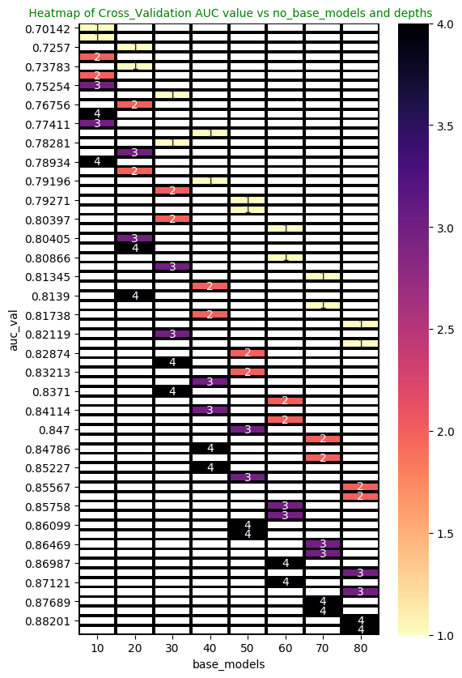

```python
#creating dataframe for pivot table:
auc_scores = []
no_base_models = []
no_depths = []

for i in range(len(cv_list)):
    auc_scores.append(cv_list[i][0])
    no_base_models.append(cv_list[i][1][0])
    no_depths.append(cv_list[i][1][1])

df_dict = dict(base_models=no_base_models,
              depths=no_depths,
              auc_val=auc_scores)
d_dframe = pd.DataFrame(df_dict)
#d_dframe.head(4)



#plotting heatmap:
fig = plt.figure(figsize=(6, 10), dpi=100)
d_pivot = d_dframe.pivot('auc_val','base_models', 'depths')
sns.heatmap(d_pivot, annot=True, cmap='magma_r', linecolor='black', linewidth=2)
plt.title(' Heatmap of Cross_Validation AUC value vs no_base_models and depths', size=10, color='green')
```

AvgW2V - XGboost

```python
# %%time

# import pickle

# file1 = open('AvgW2V_train.pickle', 'wb')
# pickle.dump(train_vector, file1)
# file1.close()

# file1 = open('AvgW2V_cv.pickle', 'wb')
# pickle.dump(cv_vector, file1)
# file1.close()

# file1 = open('AvgW2V_test.pickle', 'wb')
# pickle.dump(test_vector, file1)
# file1.close()
```

[output not shown]

W2V instance creation

```python
# import pickle

# train_vector = pickle.load(open('AvgW2V_train.pickle', 'rb'))
# cv_vector = pickle.load(open('AvgW2V_cv.pickle', 'rb'))
# test_vector = pickle.load(open('AvgW2V_test.pickle', 'rb'))

# print(train_vector.shape)
# print(cv_vector.shape)
# print(test_vector.shape)
```

```python
df.columns
```

```
Index(['index', 'Id', 'ProductId', 'UserId', 'ProfileName',
       'HelpfulnessNumerator', 'HelpfulnessDenominator', 'Score', 'Time',
       'Summary', 'Text', 'CleanedText_Bow', 'ClenedText_W2Vtfdf', 'Bow_feat',
       'Bow_new_feat', 'w2v_feat', 'w2v_new_feat'],
      dtype='object')
```

```python
df.w2v_new_feat.head(3)
```

```
0    every book educational witty little book makes...
1    whole series great way spend time child rememb...
2    entertainingl funny beetlejuice well written m...
Name: w2v_new_feat, dtype: object
```

```python
#train-test-cv split:
xtrain, xtest, ytrain, ytest = train_test_split(df.w2v_new_feat, df.Score, test_size=0.2, shuffle=False)
xtr, xcv, ytr, ycv = train_test_split(xtrain, ytrain, test_size=0.2, shuffle=False)
```

list of lists of train, cv, test data

```python
%%time

#training list of words:
train_list = []
for sentence in xtr:
    tmp_list = []
    for word in sentence.split():
        tmp_list.append(word)
    train_list.append(tmp_list)

#cv list of words
cv_list = []
for sentence in xcv:
    tmp_list = []
    for word in sentence.split():
        tmp_list.append(word)
    cv_list.append(tmp_list)

#test list of words:
test_list = []
for sentence in xtest:
    tmp_list = []
    for word in sentence.split():
        tmp_list.append(word)
    test_list.append(tmp_list)
```

```
CPU times: user 1.66 s, sys: 44 ms, total: 1.71 s
Wall time: 1.7 s
```

instantiating word2vec object for Train, cv, test data

```python
%%time
from gensim.models import Word2Vec

#instantiating training,cv, test W2V object:

trainw2v = Word2Vec(train_list, size=1000)
cvw2v = Word2Vec(cv_list, size=1000)
testw2v = Word2Vec(test_list, size=1000)

#training word2vec List:
train_vocab = list(trainw2v.wv.vocab.keys())

#cv word2vec List:
cv_vocab = list(cvw2v.wv.vocab.keys())

#test word2vec List:
test_vocab = list(testw2v.wv.vocab.keys())
```

```
CPU times: user 2min 18s, sys: 1.21 s, total: 2min 19s
Wall time: 48.9 s
```

Avg-W2V for train, cv, test data

```python
%%time

#avg-w2v for training data****************************:
train_vector = []
for sentence in train_list:
    vector = np.zeros(1000)
    for word in sentence:
        cnt = 0
        if word in train_vocab:
            vector = vector + trainw2v.wv[word]
            cnt = cnt + 1
    if cnt != 0:
        vector = vector / cnt
    train_vector.append(vector)

train_vector = np.array(train_vector)
print('train vector shape is {}'.format(train_vector.shape))


#avg-w2v for cv data***********************************:
cv_vector = []
for sentence in cv_list:
    vector = np.zeros(1000)
    for word in sentence:
        cnt = 0
        if word in cv_vocab:
            vector = vector + cvw2v.wv[word]
            cnt = cnt + 1
    if cnt != 0:
        vector = vector / cnt
    cv_vector.append(vector)

cv_vector = np.array(cv_vector)
print('cv vector shape is {}'.format(cv_vector.shape))




#avg-w2v for test data**********************************:
test_vector = []
for sentence in test_list:
    vector = np.zeros(1000)
    for word in sentence:
        cnt = 0
        if word in test_vocab:
            vector = vector + testw2v.wv[word]
            cnt = cnt + 1
    if cnt != 0:
        vector = vector / cnt
    test_vector.append(vector)

test_vector = np.array(test_vector)
print('test vector shape is {}'.format(test_vector.shape))
```

```
train vector shape is (64000, 1000)
cv vector shape is (16000, 1000)
test vector shape is (20000, 1000)
CPU times: user 15min 58s, sys: 4.45 s, total: 16min 2s
Wall time: 16min 1s
```

common class creation

```python
class XGB:

    '''building the XGboost classifier based off hypeparameters no_of_base_models and max_depth of base_models'''

    #instantiating the instance attributes:
    def __init__(self, xtr, ytr, xcv, ycv, maximum_depth=[1, 2, 3, 4], estimators=[10, 20, 30, 40]):
        self.xtr = xtr
        self.ytr = ytr
        self.xcv = xcv
        self.ycv = ycv
        self.estimators = estimators
        self.maximum_depth = maximum_depth

    #creating a method of calling RF classifier:
    def classfier(self, auc_dict_cv={}, auc_dict_tr={}):
        for estimator in self.estimators:
            for depths in self.maximum_depth:
                clf = XGBClassifier(booster='gbtree',silent=0,max_depth=depths, n_estimators=estimator, learning_rate=0.1)
                print(depths, estimator)
                clf.fit(self.xtr, self.ytr)
                y_pred_cv = clf.predict_proba(self.xcv)

                #performance metric on CV data:
                fpr_cv, tpr_cv, thresholds_cv = roc_curve(ycv, y_pred_cv[:,1])
                auc_val = auc(fpr_cv, tpr_cv)
                auc_dict_cv[auc_val] = [estimator, depths]

                #performance metrics for training data:
                y_pred_tr = clf.predict_proba(self.xtr)
                fpr_tr, tpr_tr, thresholds_tr = roc_curve(ytr, y_pred_tr[:,1])
                auc_val = auc(fpr_tr, tpr_tr)
                auc_dict_tr[auc_val] = [estimator, depths]

        return auc_dict_tr, auc_dict_cv
```

Avg W2V instance classifier

```python
import time
from xgboost.sklearn import XGBClassifier
start = time.time()
w2v_instance = XGB(train_vector, ytr, cv_vector, ycv)

dictionary_train, dictionary_cv = w2v_instance.classfier()
end = time.time()

print('time is(in seconds): ', end - start)
```

```
1 10
2 10
3 10
4 10
1 20
2 20
3 20
4 20
1 30
2 30
3 30
4 30
1 40
2 40
3 40
4 40
time is(in seconds):  436.2052698135376
```

sorting the list based off AUC score

```python
#creating dictionary :

train_list = [[np.round(x, 5), y] for x, y in dictionary_train.items()]
cv_list = [[np.round(x, 5), y] for x, y in dictionary_cv.items()]

print(train_list[0])

print()
print(cv_list[0])

tr_list = sorted(train_list, key=lambda x: x[0], reverse=True)
cv_list = sorted(cv_list, key=lambda x: x[0], reverse=True)
print('sorted train list score based off AUC score is:\n', tr_list[0:3])
print('****************************************')
print()
print('sorted CV list score based off AUC score is:\n', cv_list[0:3])
```

```
[0.83373, [10, 1]]

[0.74279, [10, 1]]
sorted train list score based off AUC score is:
 [[0.93905, [40, 4]], [0.93296, [30, 4]], [0.92832, [40, 3]]]

sorted CV list score based off AUC score is:
 [[0.847, [40, 4]], [0.84146, [40, 3]], [0.83885, [30, 4]]]
```

Plotting AUC Curve on training and cv data based off depth

[figure not shown]

```python
plt.plot([x[0] for x in tr_list], [x[1][1] for x in tr_list], linestyle='-', color='m', marker='o',label='AUC on CV data')
plt.plot([x[0] for x in cv_list], [x[1][1] for x in cv_list], linestyle='-', color='g', marker='o', label='AUC on TR data')
plt.plot([0, 1], [0, 1], linestyle='--')
plt.xlabel("no of base_classifiers")
plt.ylabel('AUC value')
plt.title('AvgW2V auc of Training vs cross validation data points', size=20, color='orange')
plt.legend()
```

Optimal Avg-W2V-XGBoost[depth = 4 and basemodels = 40]

```python
clfxgb = XGBClassifier(booster='gbtree',max_depth=4, n_estimators=40, class_weight='balanced')
clfxgb.fit(train_vector, ytr)

#prediction on training data:
y_pred_tr = clfxgb.predict_proba(train_vector)
fpr_tr, tpr_tr, thresholds_tr= roc_curve(ytr, y_pred_tr[:,1])
auc_tr = auc(fpr_tr, tpr_tr)

#prediction on test data:
ypred = clfxgb.predict_proba(test_vector)

fpr_test, tpr_test, thresholds_test= roc_curve(ytest, ypred[:,1])
auc_test = auc(fpr_test, tpr_test)

print(auc_test)
```

```
0.8496831167109989
```

plotting confusion matrix on test data

```
CPU times: user 0 ns, sys: 0 ns, total: 0 ns
Wall time: 6.44 µs
```

[figure not shown]

```python
%time
ypred = np.where(ypred[:,1] < 0.5, 0, 1)
#creating confusion matrix:

cf = confusion_matrix(ytest, ypred)
labels = ['True negative', 'True positive']

df_cf = pd.DataFrame(cf, index=labels, columns=['Predicted negative', 'Predicted positive'])
sns.heatmap(df_cf, annot=True,fmt='3d', cmap='magma_r')

plt.title("confusion Matrix Avg-W2V - RF on Test data\n", size=20)
plt.xlabel("classifier prediction values")
plt.ylabel("actual value")
plt.show()
```

plotting confusion matrix on training data

```
CPU times: user 0 ns, sys: 0 ns, total: 0 ns
Wall time: 10.5 µs
```

[figure not shown]

```python
%time
y_pred_tr = np.where(y_pred_tr[:,1] < 0.5, 0, 1)
#creating confusion matrix:

cf = confusion_matrix(ytr, y_pred_tr)
labels = ['True negative', 'True positive']

df_cf = pd.DataFrame(cf, index=labels, columns=['Predicted negative', 'Predicted positive'])
sns.heatmap(df_cf, annot=True,fmt='3d', cmap='magma_r')

plt.title("confusion Matrix Avg-W2V - RF on Training data\n", size=20)
plt.xlabel("classifier prediction values")
plt.ylabel("actual value")
plt.show()
```

ROC curve training vs test data

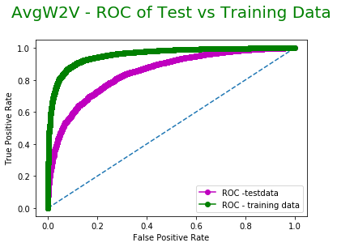

```python
plt.plot(fpr_test, tpr_test, color='m', marker='o',label='ROC -testdata')
plt.plot([0, 1], [0, 1], linestyle='--')
plt.plot(fpr_tr, tpr_tr, linestyle='-', color='g', marker='o', label='ROC - training data')
plt.xlabel('False Positive Rate')
plt.ylabel('True Positive Rate')
plt.title('AvgW2V - ROC of Test vs Training Data\n', size=20, color='green')
plt.legend()
```

Heatmap

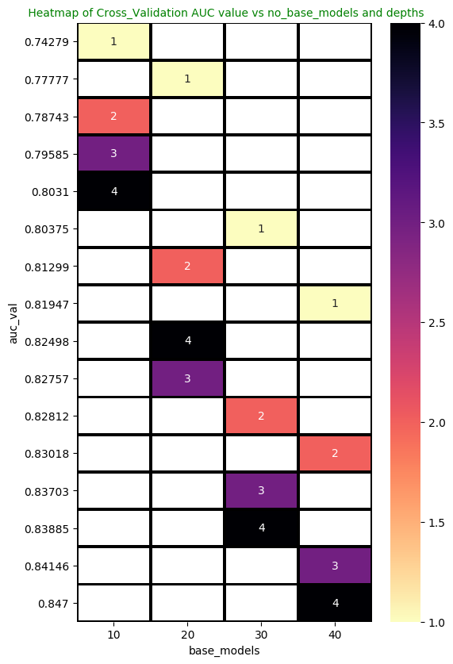

```python
#creating dataframe for pivot table:
auc_scores = []
no_base_modesl = []
no_depths = []

for i in range(len(cv_list)):
    auc_scores.append(cv_list[i][0])
    no_base_modesl.append(cv_list[i][1][0])
    no_depths.append(cv_list[i][1][1])

df_dict = dict(base_models=no_base_modesl,
              depths=no_depths,
              auc_val=auc_scores)
d_dframe = pd.DataFrame(df_dict)
#d_dframe.head(4)



#plotting heatmap:
fig = plt.figure(figsize=(6, 10), dpi=100)
d_pivot = d_dframe.pivot('auc_val','base_models', 'depths')
sns.heatmap(d_pivot, annot=True, cmap='magma_r', linecolor='black', linewidth=2)
plt.title(' Heatmap of Cross_Validation AUC value vs no_base_models and depths', size=10, color='green')
```

TFidf-W2V

importing pickeled tfidf vector files for train test nd cv data

```python
%%time

import pickle

train_vector = pickle.load(open('tfidfw2v_train.pickle', 'rb'))
cv_vector = pickle.load(open('tfidfw2v_cv.pickle', 'rb'))
test_vector = pickle.load(open('tfidfw2v_test.pickle', 'rb'))
```

```
CPU times: user 1.01 s, sys: 1.81 s, total: 2.82 s
Wall time: 2.81 s
```

conversion of list into vectors

```python
%%time
train_vector = np.array(train_vector)
cv_vector = np.array(cv_vector)
test_vector = np.array(test_vector)
```

```
CPU times: user 336 ms, sys: 348 ms, total: 684 ms
Wall time: 685 ms
```

```python
train_vector.shape, test_vector.shape, cv_vector.shape
```

```
((64000, 1000), (20000, 1000), (16000, 1000))
```

list of words creation fo rTFidf vectorizers

```python
%%time

from gensim.models import Word2Vec
from sklearn.feature_extraction.text import TfidfVectorizer

#train, cv, test split:
xtrain, xtest, ytrain, ytest = train_test_split(df.ClenedText_W2Vtfdf, df.Score, test_size=0.2, shuffle=False)
xtr, xcv, ytr, ycv = train_test_split(xtrain, ytrain, test_size=0.2, shuffle=False)


#training list of words:
train_list = []
for sentence in xtr:
    tmp_list = []
    for word in sentence.split():
        tmp_list.append(word)
    train_list.append(tmp_list)

#cv list of words:
cv_list = []
for sentence in xcv:
    tmp_list = []
    for word in sentence.split():
        tmp_list.append(word)
    cv_list.append(tmp_list)

#test list of words:
test_list = []
for sentence in xtest:
    tmp_list = []
    for word in sentence.split():
        tmp_list.append(word)
    test_list.append(tmp_list)
```

```
CPU times: user 1.43 s, sys: 324 ms, total: 1.75 s
Wall time: 1.77 s
```

TFidf dictionary creation

```python
%%time
model = TfidfVectorizer()
xtr = model.fit_transform(xtr)
xcv = model.transform(xcv)
xtest = model.transform(xtest)

# we are converting a dictionary with word as a key, and the idf as a value
dictionary = dict(zip(model.get_feature_names(), list(model.idf_)))

print(xtr.shape, xcv.shape, xtest.shape)
print(len(train_list))
```

```
(64000, 43852) (16000, 43852) (20000, 43852)
64000
CPU times: user 4.3 s, sys: 40 ms, total: 4.34 s
Wall time: 4.04 s
```

XGBoost class creation

```python
class XGB:

    '''building the XGboostRandom Forest classifier based off hypeparameters no_of_base_models and max_depth of base_models'''

    #instantiating the instance attributes:
    def __init__(self, xtr, ytr, xcv, ycv, maximum_depth=[1, 2, 3, 4], estimators=[10, 20, 30, 40]):
        self.xtr = xtr
        self.ytr = ytr
        self.xcv = xcv
        self.ycv = ycv
        self.estimators = estimators
        self.maximum_depth = maximum_depth

    #creating a method of calling RF classifier:
    def classfier(self, auc_dict_cv={}, auc_dict_tr={}):
        for estimator in self.estimators:
            for depths in self.maximum_depth:
                clf = XGBClassifier(booster='gbtree',max_depth=depths, n_estimators=estimator)
                print(depths, estimator)
                clf.fit(self.xtr, self.ytr)
                y_pred_cv = clf.predict_proba(self.xcv)

                #performance metric on CV data:
                fpr_cv, tpr_cv, thresholds_cv = roc_curve(ycv, y_pred_cv[:,1])
                auc_val = auc(fpr_cv, tpr_cv)
                auc_dict_cv[auc_val] = [estimator, depths]

                #performance metrics for training data:
                y_pred_tr = clf.predict_proba(self.xtr)
                fpr_tr, tpr_tr, thresholds_tr = roc_curve(ytr, y_pred_tr[:,1])
                auc_val = auc(fpr_tr, tpr_tr)
                auc_dict_tr[auc_val] = [estimator, depths]

        return auc_dict_tr, auc_dict_cv
```

TFIDF - W2V instance creation

```python
print(train_vector.shape, test_vector.shape, cv_vector.shape)
```

```
(64000, 1000) (20000, 1000) (16000, 1000)
```

```python
import time
from xgboost.sklearn import XGBClassifier
start = time.time()
tfidfw2v_instance = XGB(train_vector, ytr, cv_vector, ycv)

dictionary_train, dictionary_cv = tfidfw2v_instance.classfier()
end = time.time()

print('time is(in seconds): ', end - start)
```

```
1 10
2 10
3 10
4 10
1 20
2 20
3 20
4 20
1 30
2 30
3 30
4 30
1 40
2 40
3 40
4 40
time is(in seconds):  441.2281515598297
```

sorting the list based off AUC score

```python
#creating dictionary :

train_list = [[np.round(x, 5), y] for x, y in dictionary_train.items()]
cv_list = [[np.round(x, 5), y] for x, y in dictionary_cv.items()]

print(train_list[0])

print()
print(cv_list[0])

tr_list = sorted(train_list, key=lambda x: x[0], reverse=True)
cv_list = sorted(cv_list, key=lambda x: x[0], reverse=True)
print('sorted train list score based off AUC score is:\n', tr_list[0:3])
print('****************************************')
print()
print('sorted CV list score based off AUC score is:\n', cv_list[0:3])
```

```
[0.79524, [10, 1]]

[0.53041, [10, 1]]
sorted train list score based off AUC score is:
 [[0.92383, [40, 4]], [0.91417, [30, 4]], [0.90366, [40, 3]]]

sorted CV list score based off AUC score is:
 [[0.70259, [40, 3]], [0.69279, [30, 3]], [0.68579, [40, 4]]]
```

Plotting AUC Curve on training and cv data based off depth

[figure not shown]

```python
plt.plot([x[0] for x in tr_list], [x[1][1] for x in tr_list], linestyle='-', color='m', marker='o',label='AUC on CV data')
plt.plot([x[0] for x in cv_list], [x[1][1] for x in cv_list], linestyle='-', color='g', marker='o', label='AUC on TR data')
plt.plot([0, 1], [0, 1], linestyle='--')
plt.xlabel("no of base_classifiers")
plt.ylabel('AUC value')
plt.title('TFidf - W2V auc of Training vs cross validation data points', size=20, color='orange')
plt.legend()
```

Optimal TFidf - XGBoost[depth = 3 and basemodels = 40]

```python
%%time
clfxgb = XGBClassifier(booster='gbtree',max_depth=3, n_estimators=40, class_weight='balanced')
clfxgb.fit(train_vector, ytr)

#prediction on training data:
y_pred_tr = clfxgb.predict_proba(train_vector)
fpr_tr, tpr_tr, thresholds_tr= roc_curve(ytr, y_pred_tr[:,1])
auc_tr = auc(fpr_tr, tpr_tr)

#prediction on test data:
ypred = clfxgb.predict_proba(test_vector)

fpr_test, tpr_test, thresholds_test= roc_curve(ytest, ypred[:,1])
auc_test = auc(fpr_test, tpr_test)

print(auc_test)
```

```
0.7852330864428897
CPU times: user 6min 6s, sys: 1.22 s, total: 6min 7s
Wall time: 48.8 s
```

confusion matrix on test data

```
CPU times: user 0 ns, sys: 0 ns, total: 0 ns
Wall time: 7.15 µs
```

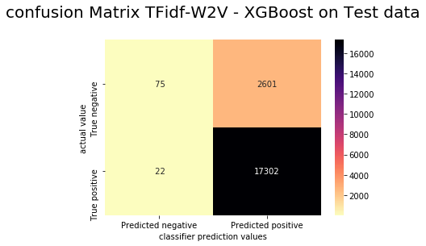

```python
%time
ypred = np.where(ypred[:,1] < 0.5, 0, 1)
#creating confusion matrix:

cf = confusion_matrix(ytest, ypred)
labels = ['True negative', 'True positive']

df_cf = pd.DataFrame(cf, index=labels, columns=['Predicted negative', 'Predicted positive'])
sns.heatmap(df_cf, annot=True,fmt='3d', cmap='magma_r')

plt.title("confusion Matrix TFidf-W2V - XGBoost on Test data\n", size=20)
plt.xlabel("classifier prediction values")
plt.ylabel("actual value")
plt.show()
```

confusion matrix on training data

```
CPU times: user 0 ns, sys: 0 ns, total: 0 ns
Wall time: 6.91 µs
```

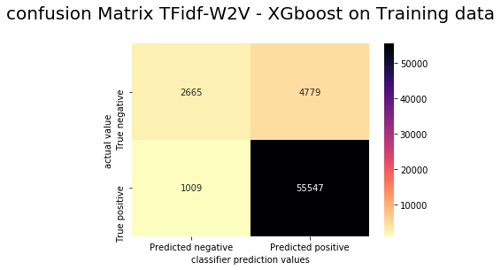

```python
%time
y_pred_tr = np.where(y_pred_tr[:,1] < 0.5, 0, 1)
#creating confusion matrix:

cf = confusion_matrix(ytr, y_pred_tr)
labels = ['True negative', 'True positive']

df_cf = pd.DataFrame(cf, index=labels, columns=['Predicted negative', 'Predicted positive'])
sns.heatmap(df_cf, annot=True,fmt='3d', cmap='magma_r')

plt.title("confusion Matrix TFidf-W2V - XGboost on Training data\n", size=20)
plt.xlabel("classifier prediction values")
plt.ylabel("actual value")
plt.show()
```

ROC curve on test data and training data

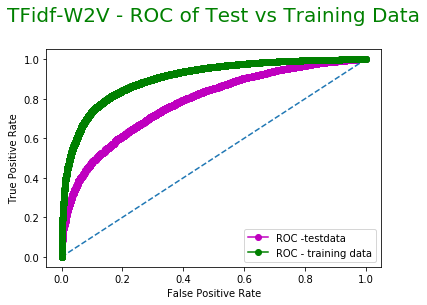

```python
plt.plot(fpr_test, tpr_test, color='m', marker='o',label='ROC -testdata')
plt.plot([0, 1], [0, 1], linestyle='--')
plt.plot(fpr_tr, tpr_tr, linestyle='-', color='g', marker='o', label='ROC - training data')
plt.xlabel('False Positive Rate')
plt.ylabel('True Positive Rate')
plt.title('TFidf-W2V - ROC of Test vs Training Data\n', size=20, color='green')
plt.legend()
```

Heatmap of CV data of AUC vs no of base models and depths

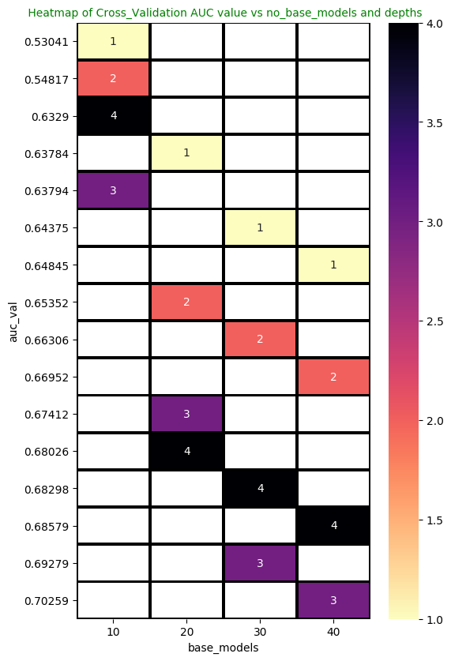

```python
#creating dataframe for pivot table:
auc_scores = []
no_base_modesl = []
no_depths = []

for i in range(len(cv_list)):
    auc_scores.append(cv_list[i][0])
    no_base_modesl.append(cv_list[i][1][0])
    no_depths.append(cv_list[i][1][1])

df_dict = dict(base_models=no_base_modesl,
              depths=no_depths,
              auc_val=auc_scores)
d_dframe = pd.DataFrame(df_dict)
#d_dframe.head(4)



#plotting heatmap:
fig = plt.figure(figsize=(6, 10), dpi=100)
d_pivot = d_dframe.pivot('auc_val','base_models', 'depths')
sns.heatmap(d_pivot, annot=True, cmap='magma_r', linecolor='black', linewidth=2)
plt.title(' Heatmap of Cross_Validation AUC value vs no_base_models and depths', size=10, color='green')
```

Performance-Measurement

```python
perf_dict = dict(Algorithm = ['Bow-RF', 'Tfidf-RF', 'AvgW2V-RF', 'TfidfW2V-RF','Bow-XGB', 'Tfidf-XGB', 'AvgW2V-XGB', 'TfidfW2V-XGB' ],
                AUC = [0.875,0.834,0.713,0.768, 0.885,0.88,0.849, 0.785 ],
                Classifiers = [15,15,5,13, 80,80,40, 40],
                Depth =[13,13,9,13,4,4,4, 3])

perf_dict = pd.DataFrame(perf_dict)
perf_dict
```

|  | AUC | Algorithm | Classifiers | Depth |
| --- | --- | --- | --- | --- |
| 0 | 0.875 | Bow-RF | 15 | 13 |
| 1 | 0.834 | Tfidf-RF | 15 | 13 |
| 2 | 0.713 | AvgW2V-RF | 5 | 9 |
| 3 | 0.768 | TfidfW2V-RF | 13 | 13 |
| 4 | 0.885 | Bow-XGB | 80 | 4 |
| 5 | 0.880 | Tfidf-XGB | 80 | 4 |
| 6 | 0.849 | AvgW2V-XGB | 40 | 4 |
| 7 | 0.785 | TfidfW2V-XGB | 40 | 3 |

***Conclusion - Out of 1L datapoints***

*1. BoW AUC performace was best amongts all the four vectorizer with ~87 % AUC score.*

*2. Applied Feature engineering on BoW vectorizers and observed AUC score was increased by 1%( ~ 88.5%)*

*3. AvgW2V-RF performace was worst amongts all the four vectorizer with ~71% AUC score.*

*4. Wordcloud creation done for BoW and TF-IDF vectorizers*

*5. Heatmap is created of AUC_Score wrt Depth and no_of_classifiers for all the 8 Vectorizers*